# Algorithm to Identify Quality of Barbell Lifts

Montserrat Perez

Friday, October 23, 2015

## Executive Summary

A group of self-movement quantification enthusiasts were asked to perform barbell lifts correctly and incorrectly in 5 different ways. The goal of this project is to find an algorithm that correclty predicts the manner in which they did the exercise. There are five possible outcomes: Class A corresponds to the specified execution of the exercise, while the other 4 classes correspond to common mistakes.

I finally applied the random forest model to the 20 test cases and achieved 100% accuracy.

## Exploratory Analysis and Data Preprocessing

We first load the data and libraries

```r
library(caret)
library(rattle)
```

```r
library(rpart.plot)
library(ggplot2)
training <-read.csv("training.csv", header=TRUE, sep=",")
test <-read.csv("test.csv", header=TRUE, sep=",")
```

We first plot the data to get an idea of balance between the different classes. This shows that class A is the one with most data volume but the other 4 classes are fairly well balanced.

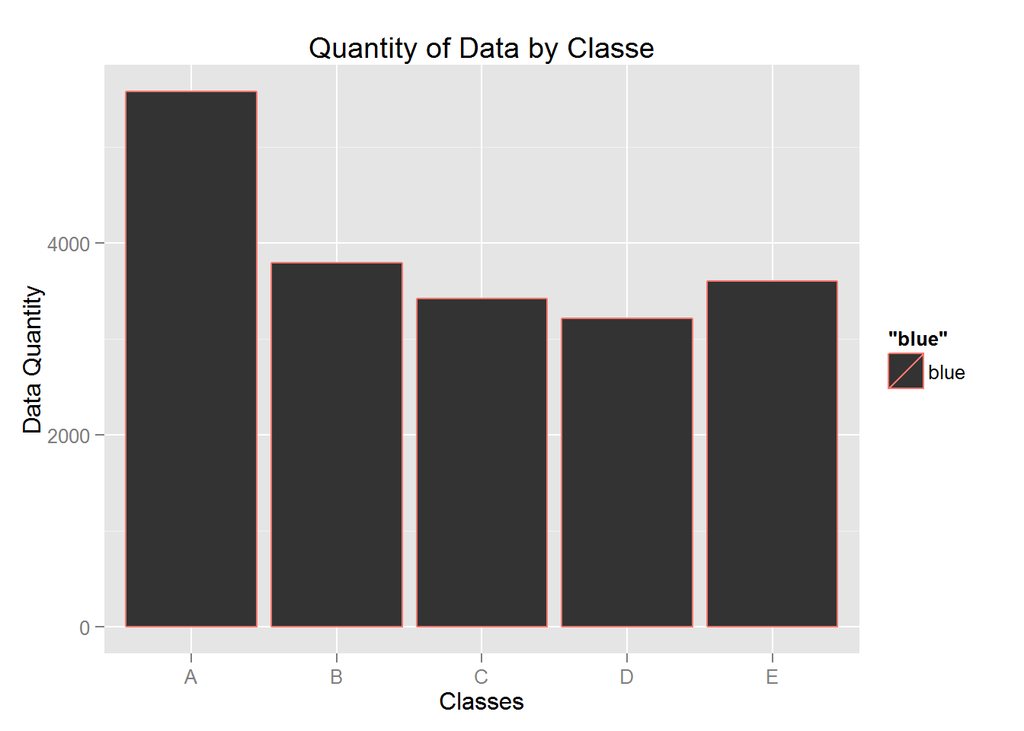

```r
qplot(training$classe, col="blue", main="Quantity of Data by Classe", xlab="Classes", ylab="Data Quantity")
```

The dataset has a large number of variables, 160 in all. On first exploration, the columns related to user name and timestamps can be removed.

```r
Remove<- c("X", "user_name", "raw_timestamp_part_1","raw_timestamp_part_2","cvtd_timestamp")
training1 <- training[, !colnames(training) %in% Remove]
test1 <- test[, !colnames(test) %in% Remove]
```

```r
Rownas <- (rowSums(is.na(training1)) == 0)
training2 <- training1[!Rownas,]
```

Next we want to remove the variables that have little variability and thus are not good predictors.

```r
nzv <- nearZeroVar(training2)
training3 <- training2[,-nzv]
test2 <- test1[,-nzv]
```

We have ended up with 54 variables (out of 160)

## Cross Validation

We now partition the data by the “classe”" variable into training and test sets so that we can test for accuracy the model derived from the training set. We will use 75% of the data for the training set.

```r
set.seed(1001)
inTrain <- createDataPartition(y= training3$classe, p=0.75, list=FALSE)
training4 <-training3[inTrain,]
test3 <-training3[-inTrain, ]
```

## Model building

Given the large number of variables a tree based model would appear appropriate. Let’s start with rpart

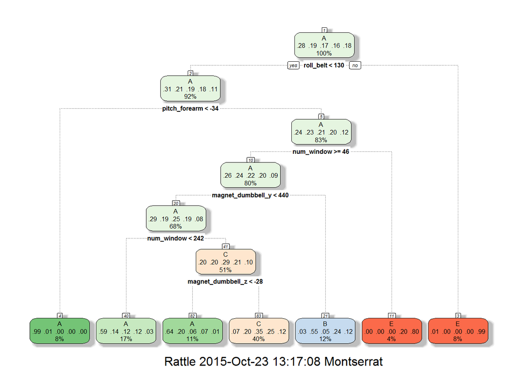

```r
tree <-train(classe ~., data=training4, method ="rpart")
rattle::fancyRpartPlot(tree$finalModel)
```

Now let’s apply the model to the test set to see how it performs out of sample.

```r
pred <-predict(tree, test3)
confusionMatrix(pred, test3$classe)
```

```
## Confusion Matrix and Statistics
##
##           Reference
## Prediction    A    B    C    D    E
##          A 1196  240  115  129   37
##          B   22  303   22  135   62
##          C  145  386  701  485  275
##          D    0    0    0    0    0
##          E    4    0    0   37  508
##
## Overall Statistics
##
##                Accuracy : 0.5639
##                  95% CI : (0.5498, 0.578)
##     No Information Rate : 0.2847
##     P-Value [Acc > NIR] : < 2.2e-16
##
##                   Kappa : 0.443
##  Mcnemar's Test P-Value : < 2.2e-16
##
## Statistics by Class:
##
##                      Class: A Class: B Class: C Class: D Class: E
## Sensitivity            0.8749   0.3262   0.8365   0.0000   0.5760
## Specificity            0.8483   0.9378   0.6743   1.0000   0.9895
## Pos Pred Value         0.6966   0.5570   0.3519      NaN   0.9253
## Neg Pred Value         0.9446   0.8530   0.9512   0.8363   0.9121
## Prevalence             0.2847   0.1935   0.1745   0.1637   0.1837
## Detection Rate         0.2491   0.0631   0.1460   0.0000   0.1058
## Detection Prevalence   0.3576   0.1133   0.4148   0.0000   0.1143
## Balanced Accuracy      0.8616   0.6320   0.7554   0.5000   0.7828
```

```r
tree1 <-train(classe ~., data=training4, method ="rf", ntree=100)
pred1 <-predict(tree1, test3)
confusionMatrix(pred1, test3$classe)
```

```
## Confusion Matrix and Statistics
##
##           Reference
## Prediction    A    B    C    D    E
##          A 1367    2    0    0    0
##          B    0  927    1    0    0
##          C    0    0  837    4    0
##          D    0    0    0  782    0
##          E    0    0    0    0  882
##
## Overall Statistics
##
##                Accuracy : 0.9985
##                  95% CI : (0.997, 0.9994)
##     No Information Rate : 0.2847
##     P-Value [Acc > NIR] : < 2.2e-16
##
##                   Kappa : 0.9982
##  Mcnemar's Test P-Value : NA
##
## Statistics by Class:
##
##                      Class: A Class: B Class: C Class: D Class: E
## Sensitivity            1.0000   0.9978   0.9988   0.9949   1.0000
## Specificity            0.9994   0.9997   0.9990   1.0000   1.0000
## Pos Pred Value         0.9985   0.9989   0.9952   1.0000   1.0000
## Neg Pred Value         1.0000   0.9995   0.9997   0.9990   1.0000
## Prevalence             0.2847   0.1935   0.1745   0.1637   0.1837
## Detection Rate         0.2847   0.1930   0.1743   0.1628   0.1837
## Detection Prevalence   0.2851   0.1933   0.1751   0.1628   0.1837
## Balanced Accuracy      0.9997   0.9988   0.9989   0.9975   1.0000
```

```r
Imp <- (varImp(tree1))
Imp
```

```
## rf variable importance
##
##   only 20 most important variables shown (out of 53)
##
##                      Overall
## num_window           100.000
## roll_belt             67.364
## pitch_forearm         40.906
## yaw_belt              32.712
## magnet_dumbbell_y     31.414
## pitch_belt            30.908
## magnet_dumbbell_z     27.652
## roll_forearm          26.830
## accel_dumbbell_y      14.194
## accel_forearm_x       10.903
## magnet_dumbbell_x     10.776
## roll_dumbbell         10.582
## magnet_belt_y          9.601
## accel_belt_z           8.936
## total_accel_dumbbell   8.587
## magnet_forearm_z       8.433
## accel_dumbbell_z       7.502
## magnet_belt_z          6.976
## magnet_belt_x          6.257
## roll_arm               5.458
```

## Apply model to 20 test cases:

```r
pred2 <-predict(tree1, test2)
pred2
```

```
##  [1] B A B A A E D B A A B C B A E E A B B B
## Levels: A B C D E
```

We achieve 100% accuracy